# TIMSS 2015 in Japan. Project 2

### Assimption 3: Studentized residuals

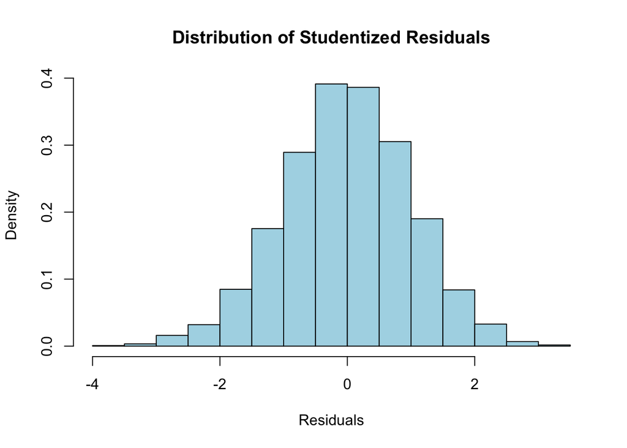

```r
library(MASS)
sresid <- studres(m5)
hist(sresid, xlab   = "Residuals", freq = FALSE,
     col    = "lightblue",
     border = "black",
     breaks = 20,
     main = "Distribution of Studentized Residuals")
```

```r
shapiro.test(sresid)
```

```
##
##  Shapiro-Wilk normality test
##
## data:  sresid
## W = 0.99886, p-value = 0.002397
```

**Interpretation:**

- The graph shows that the residuals are distributed more or less normally. This indicates that the model is good.
- However, in Shapiro-Wilk, the normality test p-value is less than 0.05, then the null hypothesis that the data are normally distributed is rejected..

### Assimption 4: Homoscedasticity

```r
bptest(m5)
```

```
##
##  studentized Breusch-Pagan test
##
## data:  m5
## BP = 29.623, df = 18, p-value = 0.04128
```

```r
ncvTest(m5)
```

```
## Non-constant Variance Score Test
## Variance formula: ~ fitted.values
## Chisquare = 6.761915, Df = 1, p = 0.0093124
```

**Interpretation:**

- I use two tests to test homoscedasticity. Unfortunately both p-value <0.05, which means there is a homoscedasticity problem in the data.

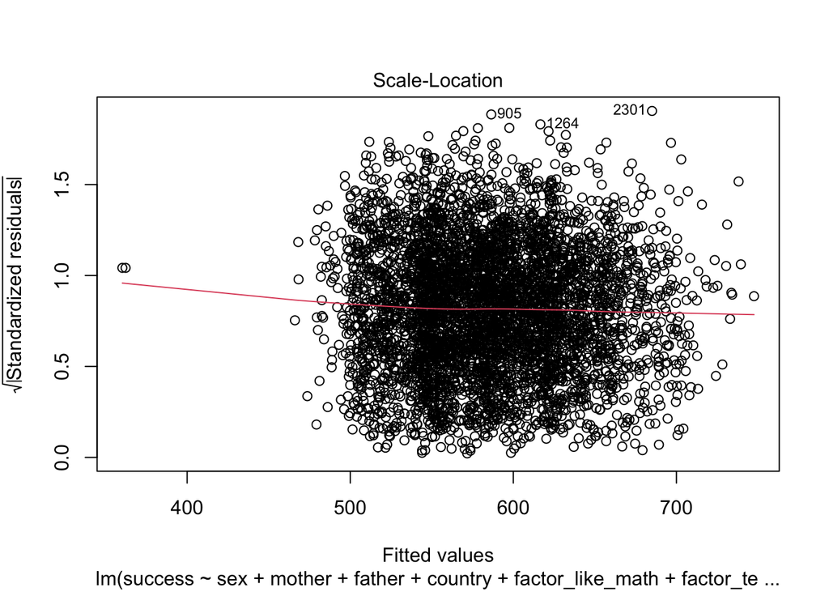

```r
plot(m5, 3)
```

**Interpretation:**

- This graph shows whether the residuals are equally distributed across the predictor ranges. It is good when the graph shows a horizontal line with equally spaced points. This is not the case in my example, so the variance is not uniform.